# Geoms and Aesthetics

Rockefeller University, Bioinformatics Resource Centre

https://rockefelleruniversity.github.io/Plotting_In_R/

These exercises cover the Geoms and Aesthetics of ggplot2 for [Plotting in R](https://rockefelleruniversity.github.io/Plotting_In_R/).

These first few exercises will run through some of the simple principles of creating a ggplot2 object, assigning aesthetics mappings and geoms.

**Exercise 1** - **Scatterplots**

- Read in the cleaned patients dataset as we saw in ggplot2 course earlier (“patients_clean_ggplot2.txt”)
- Using the patient data set generate a scatter plot of BMI versus Weight.

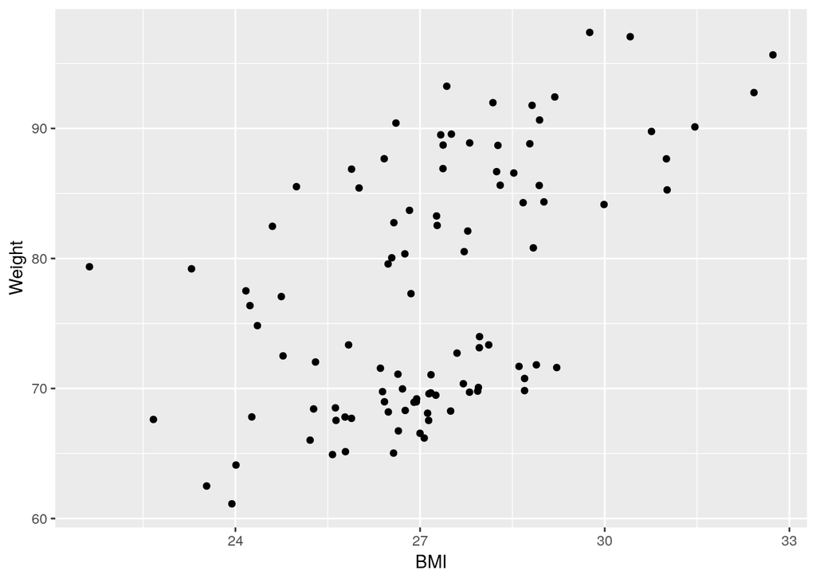

- Extend the plot by adding a color scale to the scatter plot based on the Height variable.

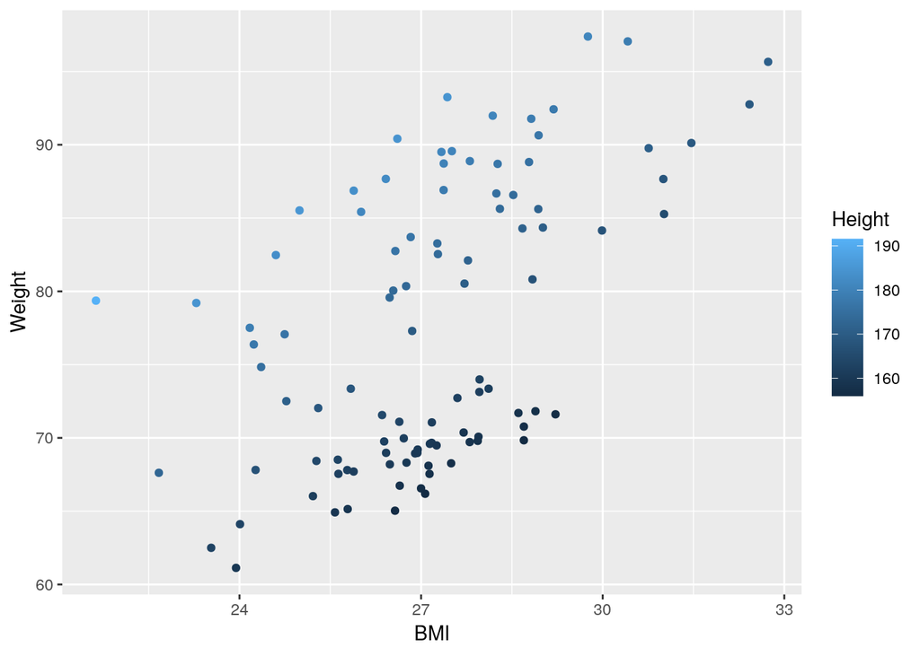

- Using an additional geom, add an extra layer of a fit line to our scatter plot.

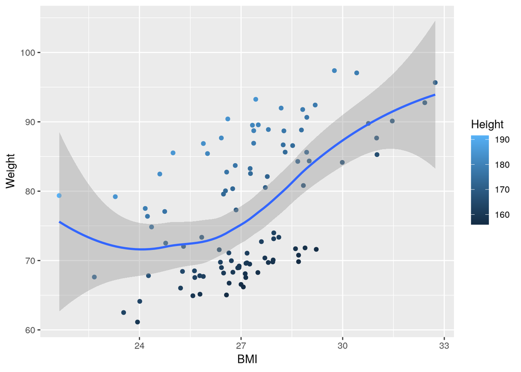

- Does the fit in look good? Look at the description for ?geom_smooth() and adjust the method for a better fit.

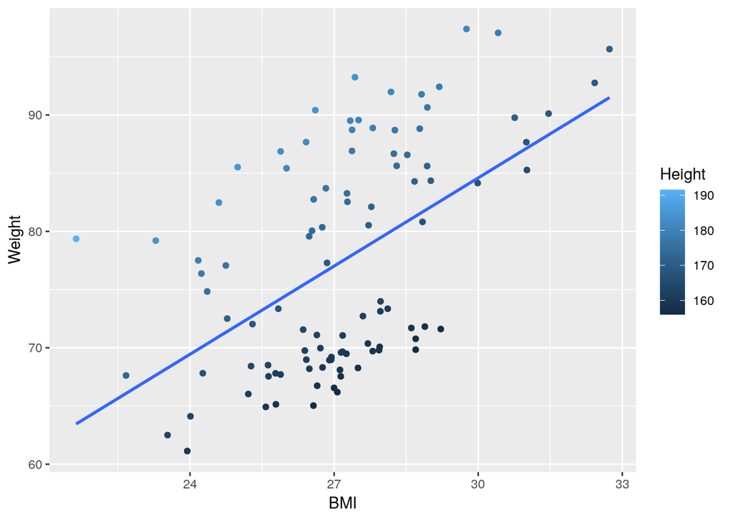

**Exercise 2** - **Boxplots, Violin and Jitter plots**

- Generate a boxplot of BMIs comparing smokers and non-smokers.

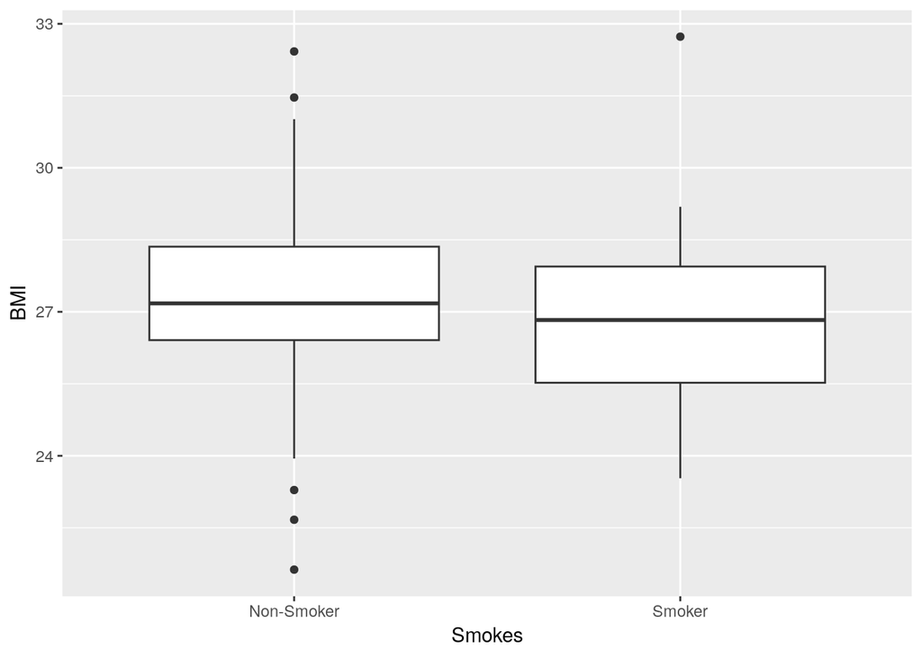

- Following from the boxplot comparing smokers and non-smokers, color the boxplot edges by Sex.

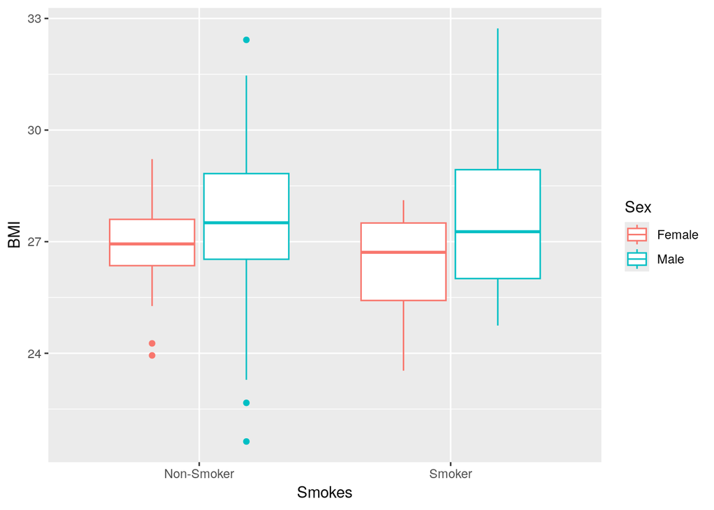

- Create a violin plot comparing the BMI between people with different pets.

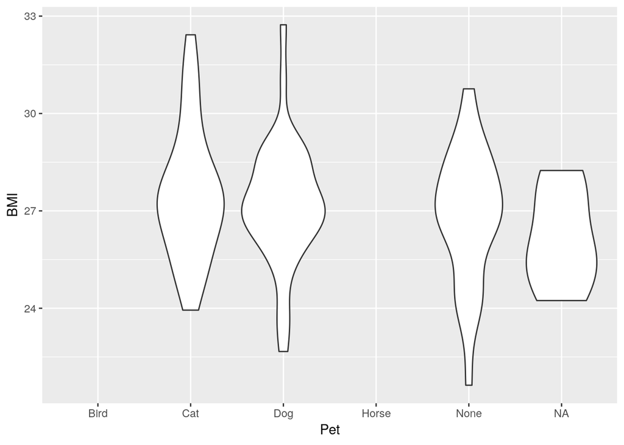

- Try out a different smoothing kernel for estimating the density. Use ?geom_violin find out more.

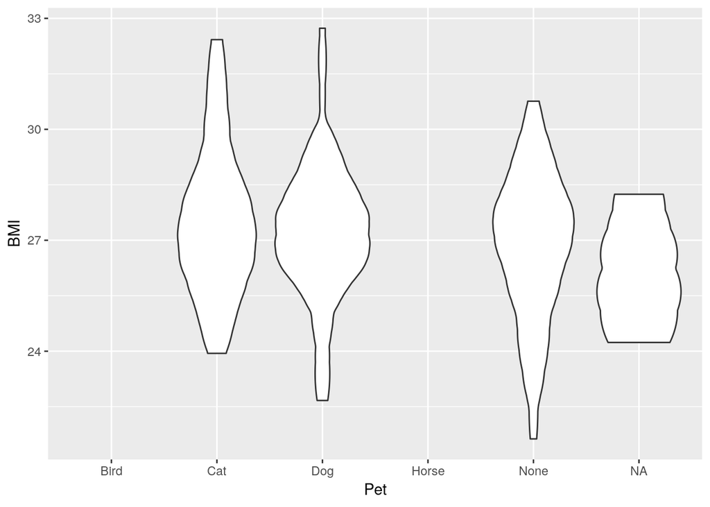

- Add both different color fills for each violin, and a jitter plot overlay.

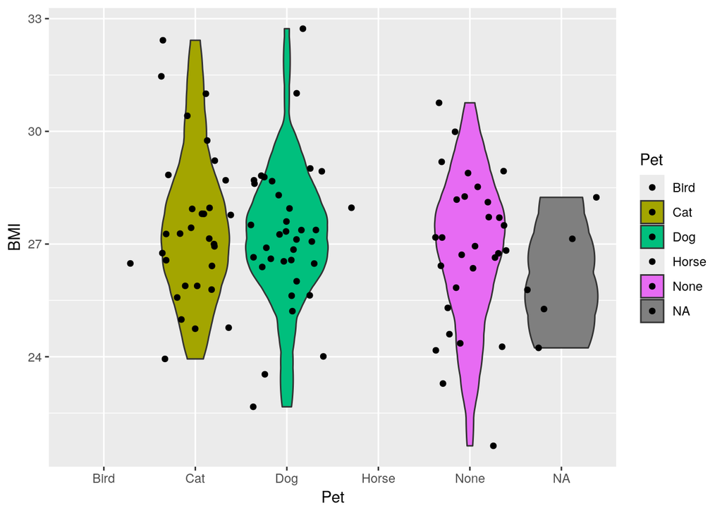

- Reduce the amount of jitter, so that points are a little more narrow.

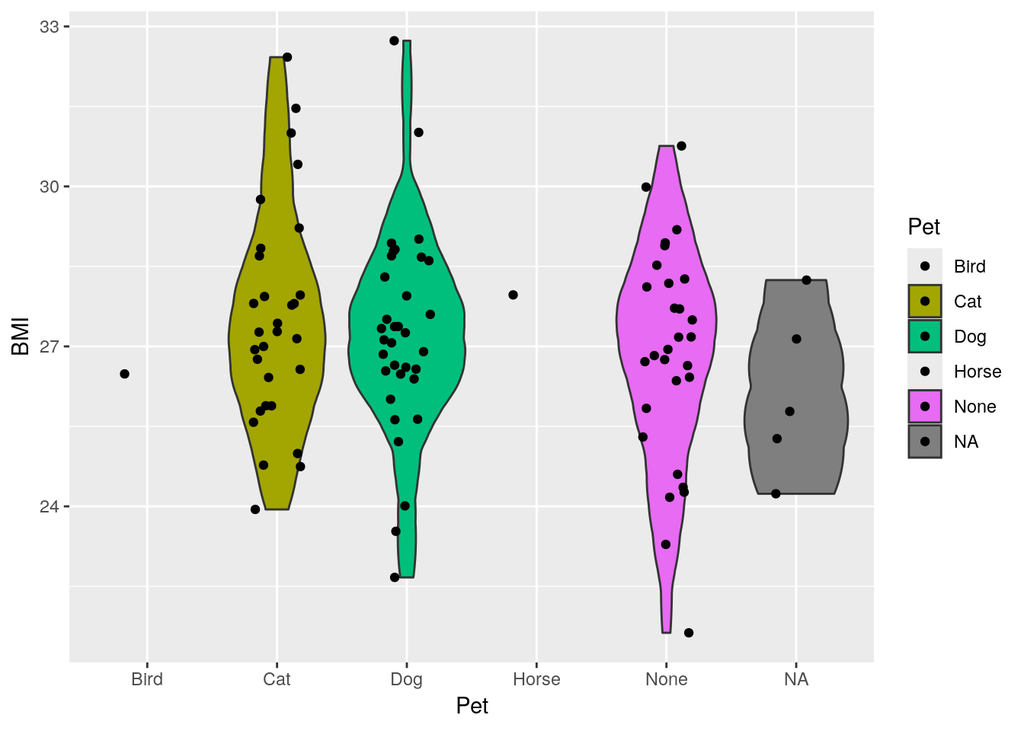

**Exercise 3** - **Histogram and Density plots**

- Generate a histogram of BMIs with each bar colored blue.

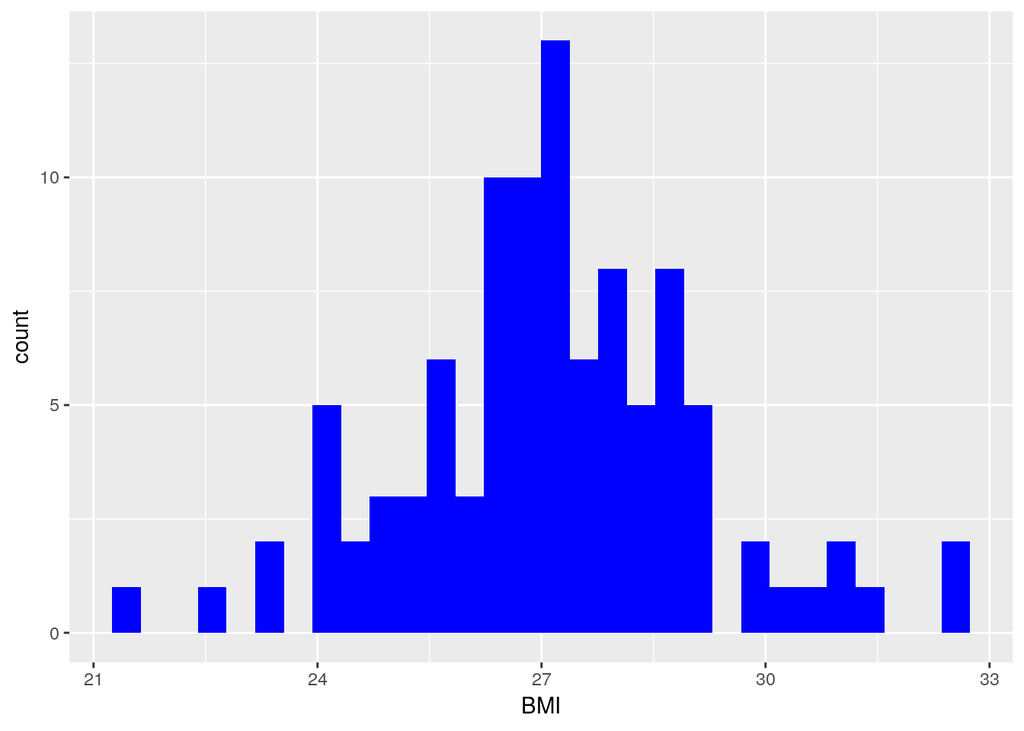

- Generate density plots of BMIs colored by Sex. Make sure you can see both distributions by adjusting the transparency.

HINT: alpha can be used to control transparency.

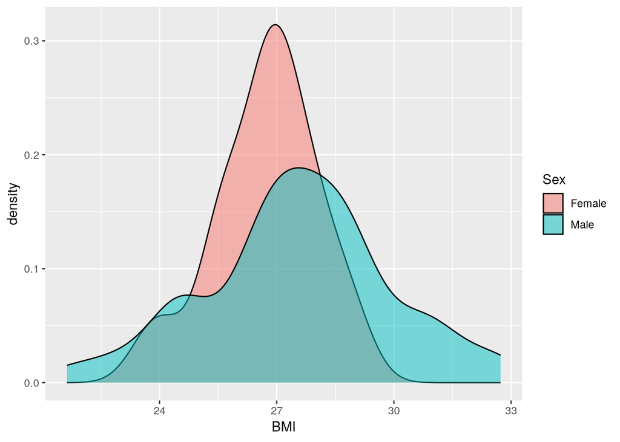

**Exercise 4** - **GGplot object**

- Take your last plot object and extract out the data from it.

```
##            ID      Name   Race Age    Sex     Smokes   Height   Weight
## 1 Patient-001 Demetrius  White  44   Male     Smoker 176.4791 77.07070
## 2 Patient-002   Rosario  White  43   Male     Smoker 174.7485 83.26835
## 3 Patient-003     Julio  Black  44   Male Non-Smoker 173.9449 85.63231
## 4 Patient-004      Lupe  White  44   Male Non-Smoker 180.0289 88.72032
## 5 Patient-005    Lavern    Cat  43   Male Non-Smoker 178.6365 97.05405
## 6 Patient-006    Bernie Native  43 Female Non-Smoker 159.7778 68.31247
##        Birth         State Pet Grade_Level  Died      Count       Date Grade
## 1 1972-02-11      New York Cat           1  TRUE -0.7440011 2015-03-04     1
## 2 1972-07-22       Florida Cat           1  TRUE -1.0714531 2015-03-04     1
## 3 1971-11-23   Connecticut Dog           2 FALSE -0.8215636 2015-03-04     2
## 4 1971-10-03 Massachusetts Dog           1  TRUE  0.4976671 2015-03-04     1
## 5 1972-11-23        Kansas Cat           3 FALSE -1.2099217 2015-03-04     3
## 6 1972-07-30      Illinois Cat           2 FALSE  0.5241618 2015-03-04     2
##        BMI Overweight
## 1 24.74586      FALSE
## 2 27.26799       TRUE
## 3 28.30182       TRUE
## 4 27.37403       TRUE
## 5 30.41397       TRUE
## 6 26.75882       TRUE
```

- Now check the aesthetic mappings

[output not shown]